# Challenge 4: Intro to Visulization: Univariate and Multivariate Graphs

Author

Kuan-Cheng Lee

Published

October 17, 2024

**Make sure you change the author’s name and add the data in the above YAML header.**

**Make sure that you are properly labeling your plots axes and legends, using colorblind-friendly palettes, and providing alt-text for all plots. You will lose points if you do not.**

## Setup

If you have not installed the following packages, please install them before loading them.

```r
library(tidyverse)
library(readxl)
library(haven) #for loading other datafiles (SAS, STATA, SPSS, etc.)
```

## Challenge Overview

In this challenge, we will practice with the data we worked on in the previous challenges and the data you choose to do some simple data visualizations using the `ggplot2` package.

There will be coding components and writing components. Please read the instructions for each part and complete your challenges.

## Datasets

- Part 1 the ESS_Polity Data (created in Challenge 3) ⭐⭐
- Part 2: the Australia Data (from Challenge 2) ⭐⭐
- Part 3: see [Part 3. Practice plotting with a dataset of your choice].

For free data sources online, see Appendix: sources for data to be used in Part 3.

Find the `_data` folder, then read the datasets using the correct R command.

## Part 1. Univariate and Multivariate Graphs (4.25 pts)

We have been working with these two data sets in the previous three challenges. Suppose we have a research project that studies European citizens’ social behaviors and public opinions, and we are interested in how the countries that respondents live in influence their behavior and opinion. In this challenge, let’s work with the combined dataset *ESS_Polity* and create some visualizations.

1. **Read the combined data you created last time. (0 pts)**

```r
#type your code/command here.
# Reading the dataset from the provided file
ess_polity <- read.csv("ESS_Polity.csv")
head(ess_polity)  # Displaying the first few rows to inspect the dataset
```

|  | idno | year | male | age | edu | eth_major | income_10 | cntry | vote | country | p5 | cyear | ccode | scode | flag | fragment | democ | autoc |
| --- | --- | --- | --- | --- | --- | --- | --- | --- | --- | --- | --- | --- | --- | --- | --- | --- | --- | --- |
| 1 | 15906 | 2010 | 0 | 14 | 1 | 1 | 2 | GR | 3 | Greece | 0 | 3502010 | 350 | GRC | 0 | 0 | 10 | 0 |
| 2 | 21168 | 2010 | 0 | 14 | 1 | 1 | 2 | IE | 3 | Ireland | 0 | 2052010 | 205 | IRE | 0 | 0 | 10 | 0 |
| 3 | 40 | 2010 | 0 | 14 | 1 | NA | 8 | LT | 3 | Lithuania | 0 | 3682010 | 368 | LIT | 0 | 0 | 10 | 0 |
| 4 | 2108 | 2010 | 0 | 14 | 1 | 1 | NA | RU | 3 | Russian Federation | NA | NA | NA | NA | NA | NA | NA | NA |
| 5 | 519 | 2010 | 0 | 14 | 1 | 1 | NA | IL | 2 | Israel | 0 | 6662010 | 666 | ISR | 0 | 3 | 7 | 1 |
| 6 | 2304 | 2010 | 0 | 14 | 1 | 1 | NA | ES | 3 | Spain | 0 | 2302010 | 230 | SPN | 0 | 0 | 10 | 0 |

2. **Suppose we are interested in the central tendencies and distributions of the following variables. At the individual level:** `age`, `male`, `edu`, `income_10`, and `vote`. **At the country level**: `democ`.

   (1) Recode the `vote` column: if the value is 1, recode it as 1; if the value is 2, recode it as 0; if the value is 3, recode it as NA. **Make sure to include a sanity check for the recoded data. (0.25 pts)**

   ```r
   #type your code/command here.
   # Recode 'vote' column using mutate
   # Recode 'vote' column: 1 -> 1, 2 -> 0, 3 -> NA
   ess_polity <- ess_polity %>%
     mutate(vote_recode = case_when(
       vote == 1 ~ 1,
       vote == 2 ~ 0,
       vote == 3 ~ NA_real_
     ))

   # Sanity check
   ess_polity %>% count(vote_recode)
   ```

   | vote_recode | n |
   | --- | --- |
   | 0 | 11432 |
   | 1 | 36804 |
   | NA | 4222 |

   (2) For each of the five variables (`age`, `edu`, `income_10`, `vote`, and `democ`), please choose an appropriate type of univariate graph to plot the central tendencies and distribution of the variables. Explain why you choose this type of graph to present a particular variable (for example: “I use a histogram to plot `age` because it is a continuous numeric variable”). **(2.5 pts)**

   **(Note: You should use at least two types of univariate graphs covered in the lecture.)**

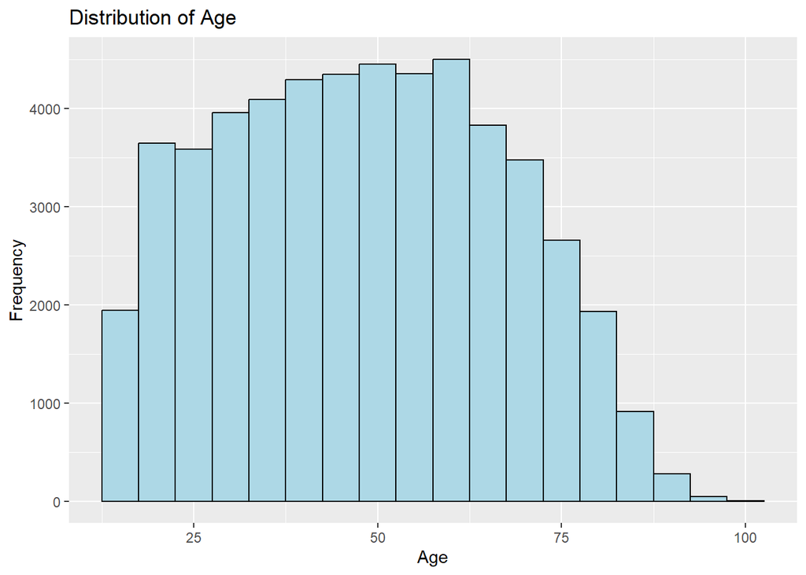

   ```r
   #type your code/command here.
   # Age Histogram
   ggplot(ess_polity, aes(x = age)) +
     geom_histogram(binwidth = 5, fill = "lightblue", color = "black") +
     ggtitle("Distribution of Age") +
     xlab("Age") + ylab("Frequency")
   ```

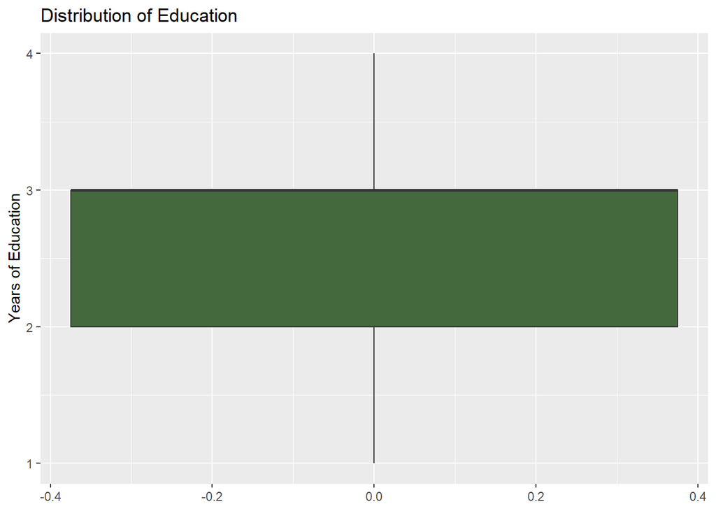

   ```r
   # Education Boxplot
   ggplot(ess_polity, aes(y = edu)) +
     geom_boxplot(fill = "#44693d") +
     ggtitle("Distribution of Education") +
     ylab("Years of Education")
   ```

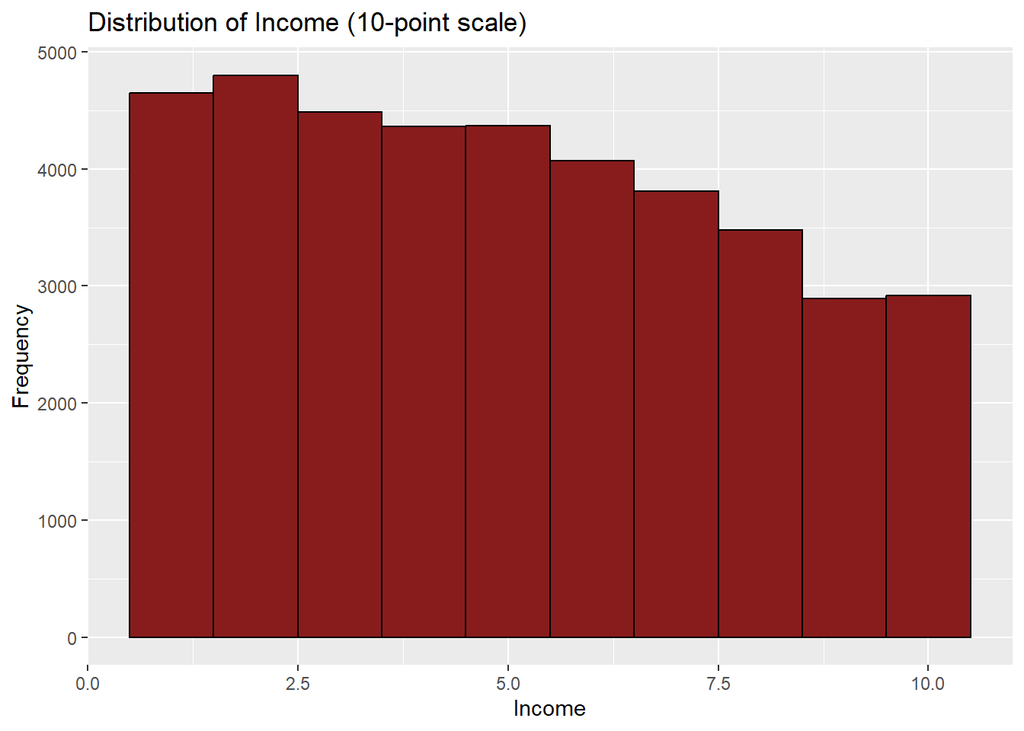

   ```r
   # Income Histogram
   ggplot(ess_polity, aes(x = income_10)) +
     geom_histogram(binwidth = 1, fill = "#881c1c", color = "black") +
     ggtitle("Distribution of Income (10-point scale)") +
     xlab("Income") + ylab("Frequency")
   ```

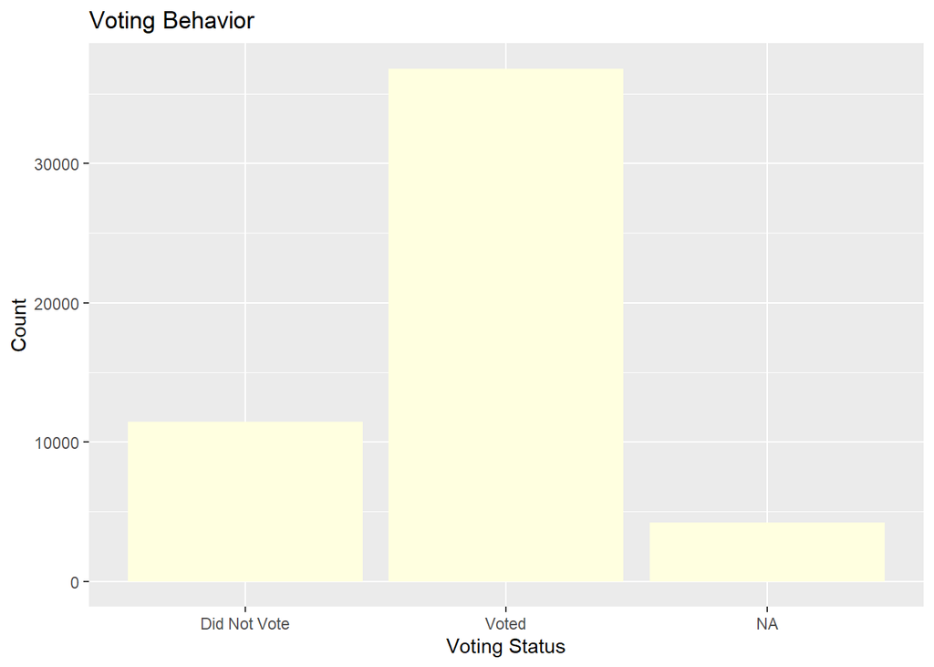

   ```r
   # Voting Behavior Bar Plot
   ggplot(ess_polity, aes(x = factor(vote_recode, labels = c("Did Not Vote", "Voted")))) +
     geom_bar(fill = "lightyellow") +
     ggtitle("Voting Behavior") +
     xlab("Voting Status") + ylab("Count")
   ```

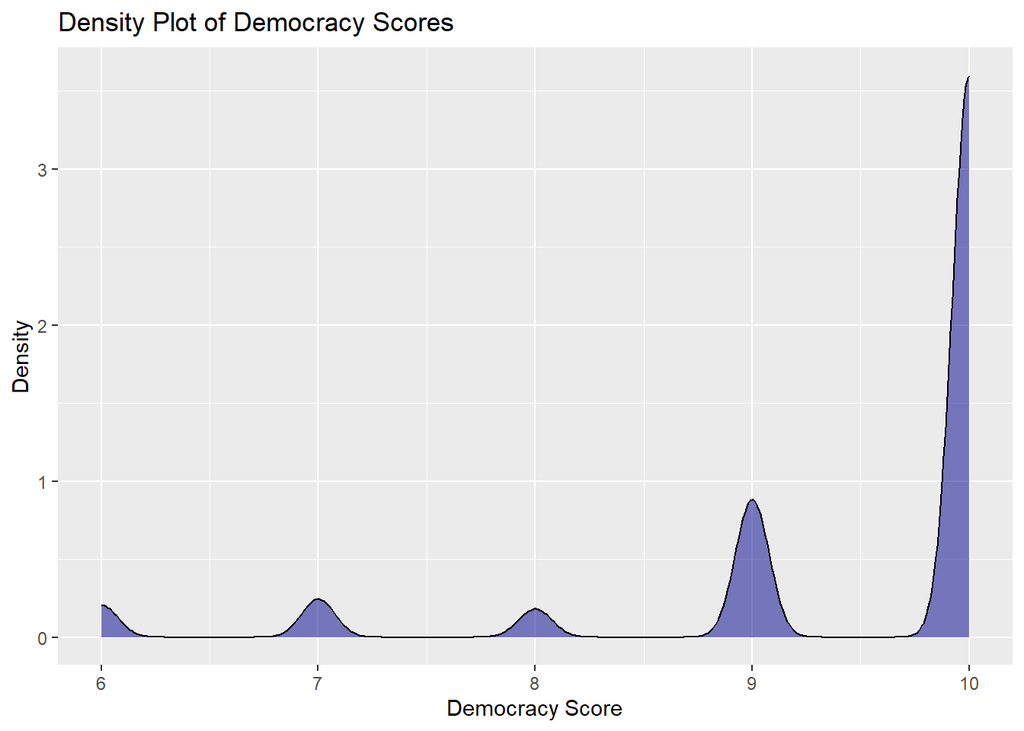

   ```r
   # Democracy Density Plot
   ggplot(ess_polity, aes(x = democ)) +
     geom_density(fill = "darkblue", alpha = 0.5) +
     ggtitle("Density Plot of Democracy Scores") +
     xlab("Democracy Score") + ylab("Density")
   ```

   (1) Hypothesis #1: The more years of education (`edu`) a person completed, the higher income (`income_10`) they earn. **(0.75 pts)**

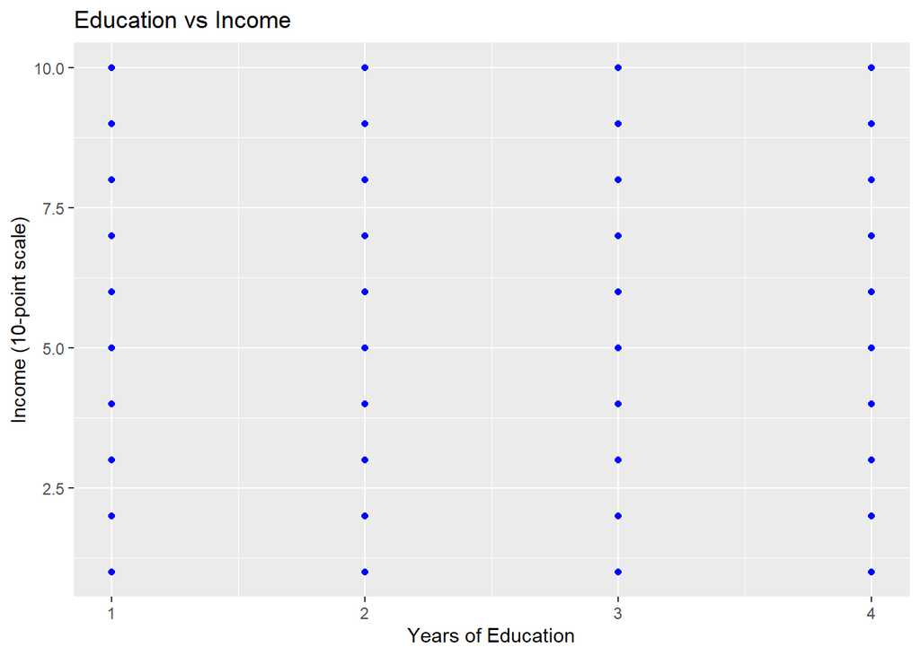

   ```r
   # Scatter plot for edu and income_10
   # Scatter plot for Education and Income
   ggplot(ess_polity, aes(x = edu, y = income_10)) +
     geom_point(color = "blue") +
     ggtitle("Education vs Income") +
     xlab("Years of Education") + ylab("Income (10-point scale)")
   ```

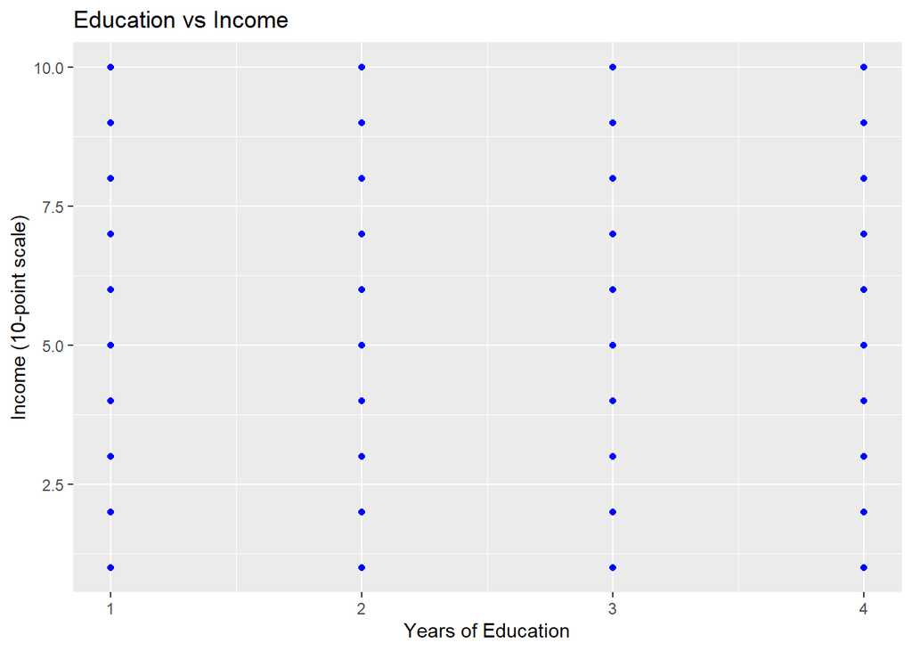

   ```r
   #type your code/command here.
   # Scatter plot for Education and Income
   ggplot(ess_polity, aes(x = edu, y = income_10)) +
     geom_point(color = "blue") +
     ggtitle("Education vs Income") +
     xlab("Years of Education") + ylab("Income (10-point scale)")
   ```

## Part 2. Comparing between Partial and Whole, and Among Groups (2.25 pts)

In this part, we will use the clean version of the Australian public opinion poll on Same-Sex Marriage to generate graphs and plots. **You may need to do data transformation or mutation to facilitate graphing.**

1. Read in data. **(0 pts)**

   ```r
   #type your code/command here.
   australian_data <- read_csv("australian_data.csv")
   ```

2. Use a barplot to graph the Australian data based on their responses: yes, no, illegible, and no response. The y-axis should be the count of responses, and each response should be represented by one individual bar (so there should be four bars). **(0.75 pts)**

   (you can use either geom_bar() or geom_col())

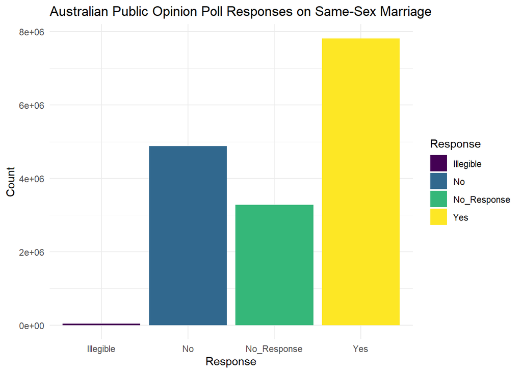

   ```r
   #type your code/command here.
   # Summing up each response type across all districts
   response_counts <- australian_data %>%
     summarise(Yes = sum(Yes),
               No = sum(No),
               Illegible = sum(Illegible),
               No_Response = sum(`No Response`)) %>%
     pivot_longer(cols = everything(), names_to = "Response", values_to = "Count")

   # Plotting the barplot
   ggplot(response_counts, aes(x = Response, y = Count, fill = Response)) +
     geom_bar(stat = "identity") +
     labs(title = "Australian Public Opinion Poll Responses on Same-Sex Marriage",
          x = "Response", y = "Count") +
     scale_fill_viridis_d() +
     theme_minimal()
   ```

3. Let’s see if there’s a relationship between Division and Response - that is, are certain divisions more likely to respond one way compared to other divisions? Again, we will use barplot(s) to present the visualization. What does your visualization tell you about the relationship between those two variables? **(1.5 pts)**

   (you can use either geom_bar() or geom_col())

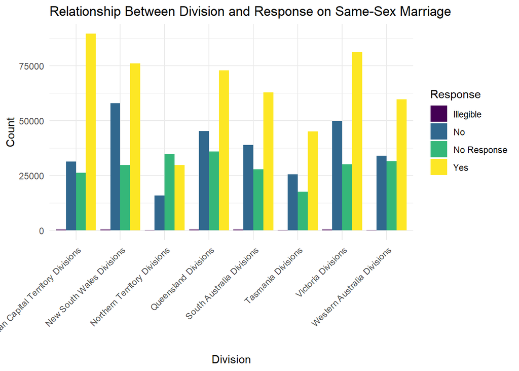

   ```r
   #type your code/command here.
   # Reshape data for Division-Response relationship
   melted_data <- australian_data %>%
     pivot_longer(cols = Yes:`No Response`, names_to = "Response", values_to = "Count")

   # Plotting the relationship between Division and Response
   ggplot(melted_data, aes(x = Division, y = Count, fill = Response)) +
     geom_bar(stat = "identity", position = "dodge") +
     labs(title = "Relationship Between Division and Response on Same-Sex Marriage",
          x = "Division", y = "Count") +
     scale_fill_viridis_d() +
     theme_minimal() +
     theme(axis.text.x = element_text(angle = 45, hjust = 1))
   ```

## Part 3. Practice plotting with a dataset of your choice (3.5 pts)

In this part, you will choose data of your interests for graphing and plotting. This data can be tidy/ready-to-be-used or raw data that needs cleaning. If the data is very large (for example, more than 20 columns), you should definitely subset the data by selecting less than 10 variables of your interests to avoid taking too much room in your R memory.

   ```r
   #type your code/command here.
   # Reload the data, specifying that the column names are on a particular row, such as the second row
   cdc_data <- read_excel("AHRFDashboard.xlsx", sheet = "AHRF Geo Data", skip = 1)
   # Check the column names again to confirm they are correct
   colnames(cdc_data) <- c('State',
                       'EMT and Paramedic, Male',
                       'Population',
                       'Rate per 100,000',
                       'Source')

   dim(cdc_data)        # To get the dimension of the data
   ```

   ```
   [1] 59  5
   ```

   ```r
   head(cdc_data)       # Inspect the first few rows
   ```

   | State | EMT and Paramedic, Male | Population | Rate per 100,000 | Source |
   | --- | --- | --- | --- | --- |
   | Selected Filters: 2022-2023 / EMT and Paramedic, Male (State Level File) / Population, All (State Level File) | NA | NA | NA | NA |
   | State/Territory | EMT and Paramedic, Male (State Level File) | Population, All (State Level File) | Rate (per 100,000 population) | Source |
   | Alabama | 1660 | 4997675 | 33.22 | American Community Survey PUMS 2017-21; American Community Survey PUMS 2017-21 |
   | Alaska | 1004 | 735951 | 136.42 | American Community Survey PUMS 2017-21; American Community Survey PUMS 2017-21 |
   | Arizona | 3168 | 7079203 | 44.75 | American Community Survey PUMS 2017-21; American Community Survey PUMS 2017-21 |
   | Arkansas | 1015 | 3006310 | 33.76 | American Community Survey PUMS 2017-21; American Community Survey PUMS 2017-21 |

   ```r
   cdc_data$`EMT and Paramedic, Male` <- as.numeric(cdc_data$`EMT and Paramedic, Male`)
   ```

```r
colnames(cdc_data)
```

```
[1] "State"                   "EMT and Paramedic, Male"
[3] "Population"              "Rate per 100,000"
[5] "Source"
```

[output not shown]

3. Choose two columns/variables that you are interest in. Plot one univariate graph for *each* of the variables. **(1 pts)**

[figure not shown]

   ```r
   # Univariate plot for "EMT and Paramedic, Male (State Level File)"
   # Univariate bar plot for "EMT and Paramedic, Male"
   ggplot(cdc_data, aes(x = 'State', y = 'EMT and Paramedic, Male')) +
     geom_bar(stat = "identity") +
     theme(axis.text.x = element_text(angle = 90, hjust = 1)) +
     labs(title = "Number of Male EMTs and Paramedics by State",
         x = "State",
         y = "Number of Male EMTs and Paramedics")
   ```

[figure not shown]

   ```r
   # Univariate plot for "Rate per 100,000"
   ggplot(cdc_data, aes(x = 'State', y = 'Rate per 100,000')) +
     geom_bar(stat = "identity") +
     theme(axis.text.x = element_text(angle = 90, hjust = 1)) +
     labs(title = "Rate of EMTs and Paramedics per 100,000 People",
         x = "State",
         y = "Rate per 100,000 Population")
   ```

4. Choose a pair of variables that may be related and make a graph (scatter plot or barplot) using them. Based on the visual evidence, do you see any potential association between the two variables? **(1.5 pts)**

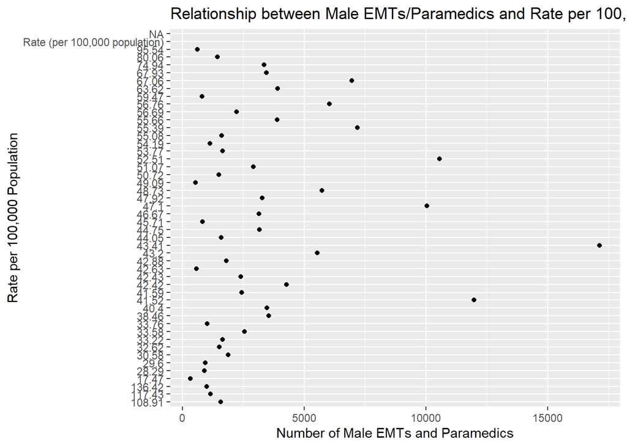

   ```r
   #type your code/command here.
   # Scatter plot for EMT and Paramedic, Male vs Rate per 100,000
   ggplot(cdc_data, aes(x = `EMT and Paramedic, Male`, y = `Rate per 100,000`)) +
     geom_point() +
     geom_smooth(method = "lm", se = FALSE, color = "blue") +  # Add linear trend line
     labs(title = "Relationship between Male EMTs/Paramedics and Rate per 100,000",
         x = "Number of Male EMTs and Paramedics",
         y = "Rate per 100,000 Population")
   ```

## Appendix: sources for data to be used in Part 3

**Here are some online sources and popular Online Dataset Hub:**

1. Many US governments (usually at the federal and state levels), bureaus, and departments have open data archives on their websites, allowing the public to access, download, and use them (for example the [CDC](https://www.cdc.gov/datastatistics/index.html)). Just use Google to search for them.
2. [**The Harvard Dataverse Repository**](https://dataverse.harvard.edu/) is a free data repository open to all researchers from any discipline, inside and outside the Harvard community, where you can share, archive, cite, access, and explore research data. Each individual Dataverse collection is a customizable collection of datasets (or a virtual repository) for organizing, managing, and showcasing datasets.
3. [**Inter-university Consortium for Political and Social Research (ICPSR)**](https://www.icpsr.umich.edu/web/pages/ICPSR/index.html) of the University of Michigan-Ann Arbor provides leadership and training in data access, curation, and methods of analysis for the social science research community.
4. [**TidyTuesday**](https://github.com/rfordatascience/tidytuesday) has many datasets expressly for the purpose of making data visualizations.
5. [**World Health Organization**](https://www.who.int/gho/database/en/)
6. [**The National Bureau of Economic Research**](https://data.nber.org/data/)
7. [**International Monetary Fund**](https://data.imf.org/?sk=388DFA60-1D26-4ADE-B505-A05A558D9A42&sId=1479329328660)
8. [**General Social Survey**](http://gss.norc.org/)
9. **UN: https://data.un.org/**
10. [**OECD Data**](https://data.oecd.org/): economic and development data of the most developed countries in the world.